# Creating a dataset

Jing Fang

# This lecture covers

- Exploring R data structures
- Using data entry
- Importing data
- Annotating datasets

# 2.1 Understanding datasets

# Understanding datasets

- A dataset is usually a rectangular array of data with rows representing observations and columns representing variables.
- We’ll use the terms *observations* and *variables* to name the rows and columns.
- R contains a wide variety of structures for holding data, including scalars, vectors, matrices, arrays, data frames, and lists.
- The data types or modes that R can handle include numeric, character, logical, complex, and raw.

# 2.2 Data structures

# Data structures

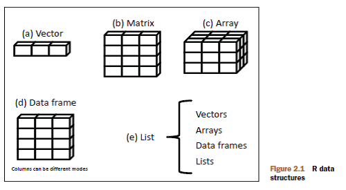

# Vectors

- Vectors are one dimensional arrays that can hold numeric data, character data, or logical data.
- The combine function `c()` is used to form the vector.
  - `a = c(1, 2, 5)`
  - `b = c("one", "two", "five")`
  - `c = c(TRUE, FALSE, TRUE)`
- The data in a vector must only be one type or mode, and you can not mix modes in the same vector.
- Scalars are one-element vector.

# Vectors

- You can refer to elements of a vector using a numeric vector of positions within brackets.

```r
a <- c(1, 2, 5, 3, 6, -2, 4)
a[3]
a[c(1, 3, 5)]
a[2:6]
```

# Vectors

```r
a <- c(1, 2, 5, 3, 6, -2, 4)
a[3]
```

```
## [1] 5
```

```r
a[c(1, 3, 5)]
```

```
## [1] 1 5 6
```

```r
a[2:6]
```

```
## [1]  2  5  3  6 -2
```

# Matrices

- A matrix is a two-dimensional array where each element has the same mode.

```r
y <- matrix(1:20, nrow = 5, ncol = 4)
y

cells <- c(1, 16, 24, 38)
rnames <- c("top", "bottom")
cnames <- c("left", "right")
mymatrix <- matrix(cells, nrow = 2, ncol = 2, byrow = TRUE, dimnames = list(rnames,
    cnames))
mymatrix

mymatrix <- matrix(cells, nrow = 2, ncol = 2, byrow = FALSE, dimnames = list(rnames,
    cnames))
mymatrix
```

# Matrices

```r
y <- matrix(1:20, nrow = 5, ncol = 4)
y
```

```
##      [,1] [,2] [,3] [,4]
## [1,]    1    6   11   16
## [2,]    2    7   12   17
## [3,]    3    8   13   18
## [4,]    4    9   14   19
## [5,]    5   10   15   20
```

```r
cells <- c(1, 16, 24, 38)
rnames <- c("top", "bottom")
cnames <- c("left", "right")
mymatrix <- matrix(cells, nrow = 2, ncol = 2, byrow = TRUE, dimnames = list(rnames,
    cnames))
mymatrix
```

```
##        left right
## top       1    16
## bottom   24    38
```

```r
mymatrix <- matrix(cells, nrow = 2, ncol = 2, byrow = FALSE, dimnames = list(rnames,
    cnames))
mymatrix
```

```
##        left right
## top       1    24
## bottom   16    38
```

# Matrices

- You can identify rows, columns, or elements of a matrix by using subscripts and brackets.

```r
x <- matrix(1:10, nrow = 2)
x
x[2, ]
x[, 2]
x[1, 4]
x[1, c(4, 5)]
```

# Matrices

```r
x <- matrix(1:10, nrow = 2)
x
```

```
##      [,1] [,2] [,3] [,4] [,5]
## [1,]    1    3    5    7    9
## [2,]    2    4    6    8   10
```

```r
x[2, ]
```

```
## [1]  2  4  6  8 10
```

```r
x[, 2]
```

```
## [1] 3 4
```

```r
x[1, 4]
```

```
## [1] 7
```

```r
x[1, c(4, 5)]
```

```
## [1] 7 9
```

# Arrays

- Arrays are similar to matrices but can have more than two dimensions.

```r
dim1 <- c("A1", "A2")
dim2 <- c("B1", "B2", "B3")
dim3 <- c("C1", "C2", "C3", "C4")
z <- array(1:24, c(2, 3, 4), dimnames = list(dim1, dim2, dim3))
z
```

# Arrays

```
## , , C1
##
##    B1 B2 B3
## A1  1  3  5
## A2  2  4  6
##
## , , C2
##
##    B1 B2 B3
## A1  7  9 11
## A2  8 10 12
##
## , , C3
##
##    B1 B2 B3
## A1 13 15 17
## A2 14 16 18
##
## , , C4
##
##    B1 B2 B3
## A1 19 21 23
## A2 20 22 24
```

# Data frames

- A data frame is more general than a matrix in that different columns can contain different modes of data.

```r
patientID <- c(1, 2, 3, 4)
age <- c(25, 34, 28, 52)
diabetes <- c("Type1", "Type2", "Type1", "Type1")
status <- c("Poor", "Improved", "Excellent", "Poor")
patientdata <- data.frame(patientID, age, diabetes, status, row.names = patientID)
patientdata
```

# Data frames

```r
patientID <- c(1, 2, 3, 4)
age <- c(25, 34, 28, 52)
diabetes <- c("Type1", "Type2", "Type1", "Type1")
status <- c("Poor", "Improved", "Excellent", "Poor")
patientdata <- data.frame(patientID, age, diabetes, status, row.names = patientID)
patientdata
```

```
##   patientID age diabetes    status
## 1         1  25    Type1      Poor
## 2         2  34    Type2  Improved
## 3         3  28    Type1 Excellent
## 4         4  52    Type1      Poor
```

# Data frames

- There are several ways to identify the elements of a data frame.

```r
patientdata[1:2]
patientdata[c("diabetes", "status")]
patientdata$age
```

# Data frames

```r
patientdata[1:2]
```

```
##   patientID age
## 1         1  25
## 2         2  34
## 3         3  28
## 4         4  52
```

```r
patientdata[c("diabetes", "status")]
```

```
##   diabetes    status
## 1    Type1      Poor
## 2    Type2  Improved
## 3    Type1 Excellent
## 4    Type1      Poor
```

```r
patientdata$age
```

```
## [1] 25 34 28 52
```

# Data frames

- The $ notation is used to indicate a particular variable from a given data frame. For example, if you want to cross tabulate diabetes type by status:

```r
table(patientdata$diabetes, patientdata$status)
```

```
##
##         Excellent Improved Poor
##   Type1         1        0    2
##   Type2         0        1    0
```

# Data frames

- It can get tired to type `patientdata$` at the beginning of every variable name, so shortcuts are available.
- The `attach()` function adds the data frame to the R search path:

  ```r
  summary(mtcars$mpg)
  plot(mtcars$mpg, mtcars$wt)
  ```

- This could also be written as:

  ```r
  attach(mtcars)
  summary(mpg)
  plot(mpg, wt)
  detach(mtcars)
  ```

- The `detach()` function removes the data frame from the search path.

# Data frames

- Of course, here we use the base graph function `plot()` in the example. If we use `qplot()` from `ggplot2` package, we can set `data=mtcars` and do not need the `attach()` and `detach()` functions.

# Data frames

- The limitations with this approach are evident when more than one object can have the same name.
- An alternative approach is to use the with() function.

```r
with(mtcars, {
    summary(mpg, wt)
    plot(mpg, wt)
})
```

# Data frames

- The limitation of the `with()` function is that assignments will only exist within the function brackets.

```r
with(mtcars, {
    stats <- summary(mpg)
    stats
})
stats
```

# Factors

- As you have seen, variables can be described as nominal, ordinal, or continuous.
  - Nominal variables are categorical, without an implied order.
  - Ordinal variables imply order but not amount.
  - Continuous variables can take on any value within some range, and both order and amount are implied.
- Categorical and ordered categorical variables in R are called factors.

# Factors

- The function `factor()` stores the categorical values as a vector of integers, and an internal vector of character strings mapped to these integers.

```r
diabetes <- c("Type1", "Type2", "Type1", "Type1")
diabetes <- factor(diabetes)
diabetes
```

```
## [1] Type1 Type2 Type1 Type1
## Levels: Type1 Type2
```

```r
status <- c("Poor", "Improved", "Excellent", "Poor")
status <- factor(status, ordered = TRUE)
status
```

```
## [1] Poor      Improved  Excellent Poor
## Levels: Excellent < Improved < Poor
```

# Factors

- By default, factors levels for character vectors are created in alphabetical order.
- You can override the default by specifying a `levels` option.

```r
status <- factor(status, ordered = TRUE, levels = c("Poor", "Improved", "Excellent"))
status
```

```
## [1] Poor      Improved  Excellent Poor
## Levels: Poor < Improved < Excellent
```

# Factors

```r
patientID <- c(1, 2, 3, 4)
age <- c(25, 34, 28, 52)
diabetes <- c("Type1", "Type2", "Type1", "Type1")
status <- c("Poor", "Improved", "Excellent", "Poor")
diabetes <- factor(diabetes)
status <- factor(status, ordered = TRUE)
patientdata <- data.frame(patientID, age, diabetes, status, row.names = patientID)
str(patientdata)
```

```
## 'data.frame':    4 obs. of  4 variables:
##  $ patientID: num  1 2 3 4
##  $ age      : num  25 34 28 52
##  $ diabetes : Factor w/ 2 levels "Type1","Type2": 1 2 1 1
##  $ status   : Ord.factor w/ 3 levels "Excellent"<"Improved"<..: 3 2 1 3
```

```r
summary(patientdata)
```

```
##    patientID         age        diabetes       status
##  Min.   :1.00   Min.   :25.0   Type1:3   Excellent:1
##  1st Qu.:1.75   1st Qu.:27.2   Type2:1   Improved :1
##  Median :2.50   Median :31.0             Poor     :2
##  Mean   :2.50   Mean   :34.8
##  3rd Qu.:3.25   3rd Qu.:38.5
##  Max.   :4.00   Max.   :52.0
```

# Lists

- A list is an ordered collection of objects to allows you to gather a variety of them under one name.

```r
g <- "My First List."
h <- c(25, 26, 18, 39)
j <- matrix(1:10, nrow = 5)
k <- c("one", "two", "three")
mylist <- list(title = g, ages = h, j, k)
mylist
```

```
## $title
## [1] "My First List."
##
## $ages
## [1] 25 26 18 39
##
## [[3]]
##      [,1] [,2]
## [1,]    1    6
## [2,]    2    7
## [3,]    3    8
## [4,]    4    9
## [5,]    5   10
##
## [[4]]
## [1] "one"   "two"   "three"
```

# Lists

```r
mylist[[4]]
```

```
## [1] "one"   "two"   "three"
```

```r
mylist[["ages"]]
```

```
## [1] 25 26 18 39
```

# Lists

- A note for programmers
  - The (.) has no special significance in object name, but the ($) has a analogous meaning.
  - R does not provide multiline or block comments.
  - Assigning a value to a nonexistent element of a data structure, will expand it to accommodate the new value.
  - R does not have scalar values, but one element vectors.
  - Indices in R start at 1, not at 0.
  - Variables can not be declared.

# 2.3 Data input

# Data input

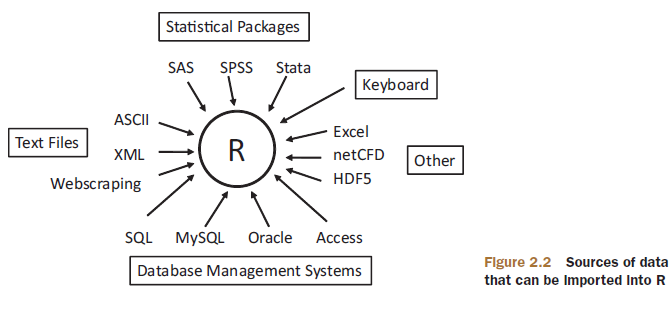

# Data input

- The best way to read other files is to export it to a comma-delimited file and import it to R.
- You can import data from delimited text files using `read.table()`

  ```r
  grades <- read.table("studentgrades.csv", header = TRUE, sep = ",", row.names = "studentID",
      stringsAsFactors = FALSE)
  ```

- See `help(read.table)` for details.
- The `foreign` package can help you too.

# 2.4 Useful functions for working with data objects

# Useful functions for working with data objects

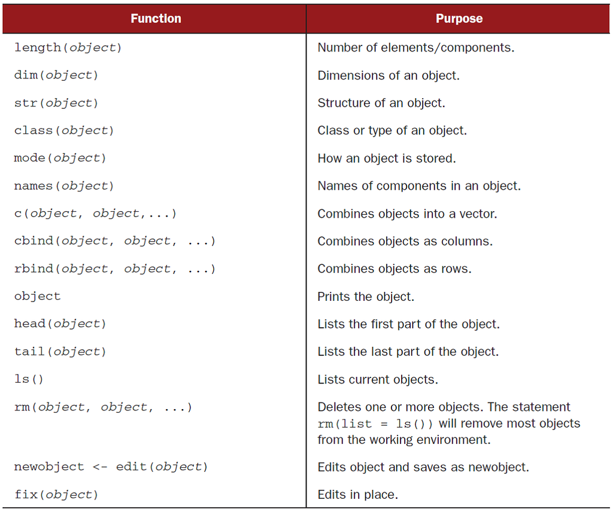